# Meta-analysis physiological costs of hibernation: Report 2 - IM Hibernation

Pablo Capilla-Lasheras

2026-05-04

This [R Markdown](http://rmarkdown.rstudio.com) Notebook contains the initial meta-analysis for the project ‘physiological ’costs’ of hibernation. Specifically, the meta-analysis of hibernation.

## Dataset and calculation of effect sizes

The dataset for this meta-analysis has been collected from the literature and curated by Pablo Burraco, Marko Prokic and Tamara Petrovic. It contains data on physiological effects of hibernation in different systems. Here a quick snapshot of the first lines of the dataset:

```r
# dataset with raw data
data <- openxlsx::read.xlsx(
  here(
    "./01_data/raw_data/Burraco_et_al_hibernation_hibernation.xlsx"
  ),
  colNames = T,
  sheet = 2
)

paged_table(data, options = list(rows.print = 20))
```

|  | Reference | Year | StudyID | Species | Thermoregulation | Class | Ver_Invert | Experiment_venue | Tissue | Biomarker_category | Specific_marker | Unit | Euthermia_N | Euthermia_M | Euthermia_SD | Euthermia_SE | Hib_N | Hib_M | Hib_SD | Hib_SE | sign_under_stress |
| --- | --- | --- | --- | --- | --- | --- | --- | --- | --- | --- | --- | --- | --- | --- | --- | --- | --- | --- | --- | --- | --- |
| 1 | Bauma et al., 2013 | 2013 | study544 | Ictidomys tridecemlineatus | Endothermic | Mammalia | Vertebrate | laboratory | blood | Adaptive | CD4 | 10^6/mL | 13 | 9.777778e-01 | NA | 1.572650e-01 | NA | NA | NA | NA | negative |
| 2 | Bauma et al., 2013 | 2013 | study544 | Ictidomys tridecemlineatus | Endothermic | Mammalia | Vertebrate | laboratory | blood | Adaptive | CD45RA | 10^6/mL | 13 | 2.393162e-01 | NA | 2.735043e-02 | NA | NA | NA | NA | negative |
| 3 | Bauma et al., 2013 | 2013 | study544 | Ictidomys tridecemlineatus | Endothermic | Mammalia | Vertebrate | laboratory | blood | Adaptive | CD8 | 10^6/mL | 13 | 3.555556e-01 | NA | 5.470085e-02 | NA | NA | NA | NA | negative |
| 4 | Bohr et al., 2014 | 2014 | study543 | Ictidomys tridecemlineatus | Endothermic | Mammalia | Vertebrate | laboratory | lung | Both | CD11b/c+ | % FSC versus SSC gated population | 11 | 1.015000e+01 | NA | 1.550000e+00 | 12 | 1.840000e+01 | NA | 2.330000e+00 | positive |
| 5 | Bohr et al., 2014 | 2014 | study543 | Ictidomys tridecemlineatus | Endothermic | Mammalia | Vertebrate | laboratory | lung | Adaptive | CD3+ | % FSC versus SSC gated population | 12 | 5.476000e+01 | NA | 3.650000e+00 | 13 | 3.422000e+01 | NA | 4.200000e+00 | negative |
| 6 | Bohr et al., 2014 | 2014 | study543 | Ictidomys tridecemlineatus | Endothermic | Mammalia | Vertebrate | laboratory | lung | Adaptive | CD45RA+ | % FSC versus SSC gated population | 12 | 9.700000e-01 | NA | 2.400000e-01 | 13 | 8.300000e-01 | NA | 2.400000e-01 | negative |
| 7 | Bohr et al., 2014 | 2014 | study543 | Ictidomys tridecemlineatus | Endothermic | Mammalia | Vertebrate | laboratory | lung | Innate | E-selectin | Normalized Densitometric Units | 6 | 5.118959e-02 | NA | 2.743494e-02 | 6 | 6.390335e-02 | NA | 2.040892e-02 | positive |
| 8 | Bohr et al., 2014 | 2014 | study543 | Ictidomys tridecemlineatus | Endothermic | Mammalia | Vertebrate | laboratory | lung | Adaptive | IgA | Normalized Densitometric Units | 6 | 3.568773e-01 | NA | 5.204461e-03 | 6 | 3.680297e-01 | NA | 4.460967e-03 | positive |
| 9 | Bohr et al., 2014 | 2014 | study543 | Ictidomys tridecemlineatus | Endothermic | Mammalia | Vertebrate | laboratory | lung | Both | IL-10 | pg/mg protein | 6 | 3.245009e+00 | NA | 4.428312e-01 | 6 | 1.887477e+00 | NA | 3.121597e-01 | positive |
| 10 | Bohr et al., 2014 | 2014 | study543 | Ictidomys tridecemlineatus | Endothermic | Mammalia | Vertebrate | laboratory | lung | Innate | SOCS1 Expression | Normalized Densitometric Units | 6 | 3.378866e-01 | NA | 6.185567e-02 | 6 | 3.711340e-02 | NA | 1.701031e-02 | NA |

[output cut: 225 more lines]

As a summary of the *initial dataset*:

- Number of studies: 20
- Number of species: 12

For this initial meta-analysis, I am going to include all immune (IM) markers and calculate the standarised mean difference (g; with heteroscedastic population variances) as the effect size of analysis comparing **hibernation** *versus* **euthermia**. Positive SMD values indicate higher IM values in *hibernation* while negative SMD indicate lower IM values in hibernation. This is a summary of the effect size calculation based on the dataset above:

```r
# ES data
data <- readRDS(
  here(
    "./01_data/processed_RDS_data_files/02_IM_metaanalysis_hibernation_full_data.RDS"
  )
)
data$obsID <- 1:nrow(data) # observation ID

# handling species names for phylogenetic-controlled models
data$Species <- replace_values(
  data$Species,
  "Lithobates pipiens" ~ "Rana pipiens"
)

data$scientific_name <- gsub(
  x = data$Species,
  pattern = "_",
  replacement = " "
)

data$scientific_name_phylo <- data$scientific_name

## data for SMD
df_SMD <- data %>%
  filter(!is.na(SMDH)) %>%
  filter(!is.na(SMDH.sv))

# matrix with phylogentic correlations
phylo_cor <- readRDS(
  here(
    "./01_data/processed_RDS_data_files/02_IM_phylogenetic_correlations_hibernation.RDS"
  )
)

phylo_tree <- readRDS(
  here(
    "./01_data/processed_RDS_data_files/02_IM_phylogenetic_tree_hibernation.RDS"
  )
)

tree <- ggtree(phylo_tree, size = 1.2) +
  xlim_tree(c(0, 35)) +
  geom_tiplab(
    aes(
      label = paste0(
        "italic('",
        sub(x = label, pattern = "_", replacement = " "),
        "')"
      )
    ),
    parse = TRUE,
    offset = 0.5,
    size = 5,
    hjust = 0
  )

ggsave(
  filename = here(
    "./03_plots/01_hibernation/00b_IM_phylo_tree.png"
  ),
  plot = tree,
  device = "png",
  height = 150,
  width = 90,
  units = "mm"
)

ggsave(
  filename = here(
    "./03_plots/01_hibernation/00b_IM_phylo_tree.pdf"
  ),
  plot = tree,
  height = 150,
  width = 90,
  units = "mm"
)
```

Summary of SMD effect size and number of observations included in the meta-analysis:

```r
summary(df_SMD$SMDH)
```

```
##     Min.  1st Qu.   Median     Mean  3rd Qu.     Max.
## -9.40248 -0.96256  0.07434 -0.21881  0.89528  9.37814
```

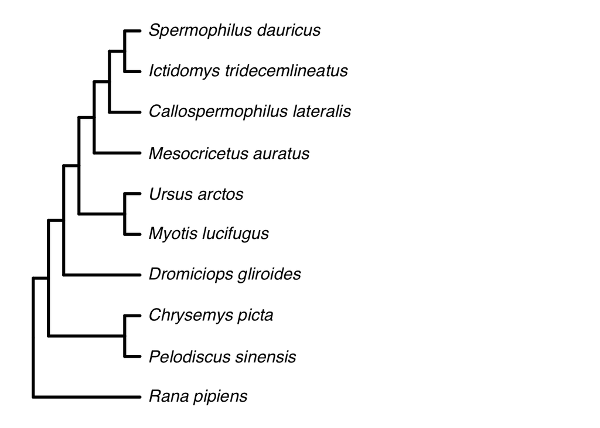

```r
print(tree)
```

- Number of observation with non-missing SMD: 218
- Number of studies in the dataset for analysis: 17
- Number of species in the dataset for analysis: 10

## Initial meta-analysis:

This initial model contains only the intercept and four random effects to account for phylogenetic variation and variation between and within studies beyond sampling variance.

```r
## calculate var-cover matrix to control for correlated effect sizes within study and tissue
V <- vcalc(
  vi = SMDH.sv,
  cluster = StudyID,
  subgroup = Tissue,
  grp1 = Hib_M,
  grp2 = Euthermia_M,
  w1 = Hib_N,
  w2 = Euthermia_N,
  data = df_SMD
)

# model
model_SMD <- rma.mv(
  yi = SMDH,
  V = V,
  mods = ~1,
  random = list(
    ~ 1 | scientific_name_phylo,
    ~ 1 | Species,
    ~ 1 | obsID,
    ~ 1 | StudyID
  ),
  data = df_SMD,
  R = list(scientific_name_phylo = phylo_cor),
  method = "REML",
  control = list(optimizer = "BFGS"),
  verbose = F
)
```

```r
saveRDS(
  object = model_SMD,
  file = here(
    './04_models/01_hibernation/01b_metamodel_hibernation_IM.RDS'
  )
)
model_SMD <- readRDS(
  file = here(
    './04_models/01_hibernation/01b_metamodel_hibernation_IM.RDS'
  )
)
summary(model_SMD)
```

```
##
## Multivariate Meta-Analysis Model (k = 212; method: REML)
##
##    logLik   Deviance        AIC        BIC       AICc
## -379.9761   759.9523   769.9523   786.7116   770.2449
##
## Variance Components:
##
##             estim    sqrt  nlvls  fixed                 factor    R
## sigma^2.1  1.5506  1.2452      9     no  scientific_name_phylo  yes
## sigma^2.2  0.0000  0.0038      9     no                Species   no
## sigma^2.3  0.6646  0.8152    212     no                  obsID   no
## sigma^2.4  0.9236  0.9610     16     no                StudyID   no
##
## Test for Heterogeneity:
## Q(df = 211) = 741.1496, p-val < .0001
##
## Model Results:
##
## estimate      se     zval    pval    ci.lb   ci.ub
##  -1.1146  0.7685  -1.4503  0.1470  -2.6208  0.3917
##
## ---
## Signif. codes:  0 '***' 0.001 '**' 0.01 '*' 0.05 '.' 0.1 ' ' 1
```

```r
i2_SMD <- round(i2_ml(model_SMD), digits = 4) # heterogeneity random effects
```

Proportion of variation left after accounting for sampling variance and proportion accounted by each random effect:

```r
knitr::kable(
  x = data.frame(
    Variable = names(i2_SMD),
    i2_value_percentage = as.numeric(round(i2_SMD, digits = 3))
  )
) %>%
  kableExtra::kable_styling(full_width = F)
```

| Variable | i2_value_percentage |
| --- | --- |
| I2_Total | 89.429 |
| I2_scientific_name_phylo | 44.179 |
| I2_Species | 0.000 |
| I2_obsID | 18.935 |
| I2_StudyID | 26.315 |

### Plot of results of intercept-only model:

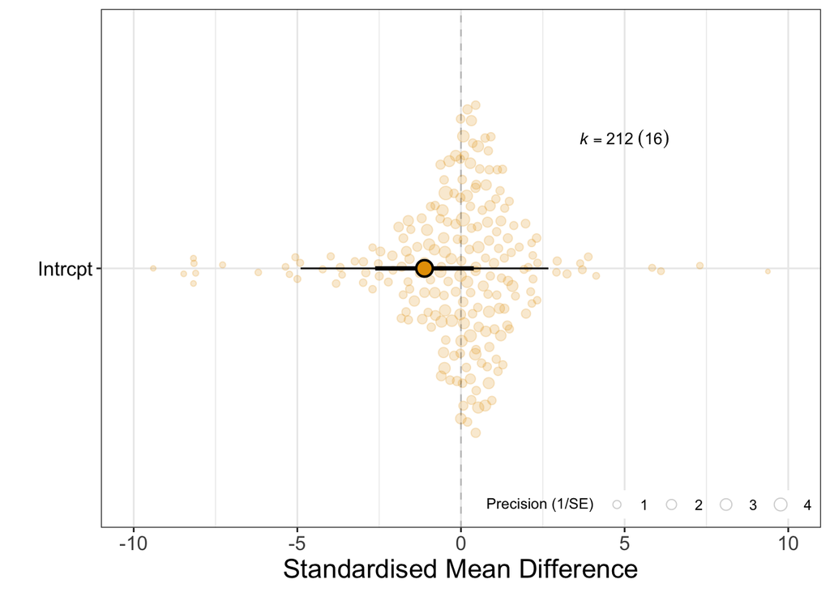

### Publication bias: small-study effects

```r
df_SMD$inv_eff_ss <- (1 / df_SMD$Hib_N) + (1 / df_SMD$Euthermia_N)


model_SMD_pb <- rma.mv(
  yi = SMDH,
  V = V,
  mods = ~ 1 + sqrt(inv_eff_ss),
  random = list(
    ~ 1 | scientific_name_phylo,
    ~ 1 | Species,
    ~ 1 | obsID,
    ~ 1 | StudyID
  ),
  data = df_SMD,
  R = list(scientific_name_phylo = phylo_cor),
  method = "REML",
  control = list(optimizer = "BFGS"),
  verbose = F
)
```

```r
saveRDS(
  object = model_SMD_pb,
  file = here(
    './04_models/01_hibernation/06b_pb_metamodel_hibernation_IM.RDS'
  )
)
model_SMD_pb <- readRDS(
  file = here(
    './04_models/01_hibernation/06b_pb_metamodel_hibernation_IM.RDS'
  )
)

summary(model_SMD_pb)
```

```
##
## Multivariate Meta-Analysis Model (k = 212; method: REML)
##
##    logLik   Deviance        AIC        BIC       AICc
## -378.0465   756.0930   768.0930   788.1756   768.5068
##
## Variance Components:
##
##             estim    sqrt  nlvls  fixed                 factor    R
## sigma^2.1  1.6171  1.2716      9     no  scientific_name_phylo  yes
## sigma^2.2  0.0000  0.0043      9     no                Species   no
## sigma^2.3  0.6705  0.8188    212     no                  obsID   no
## sigma^2.4  0.9503  0.9748     16     no                StudyID   no
##
## Test for Residual Heterogeneity:
## QE(df = 210) = 738.7382, p-val < .0001
##
## Test of Moderators (coefficient 2):
## QM(df = 1) = 0.1925, p-val = 0.6608
##
## Model Results:
##
##                   estimate      se     zval    pval    ci.lb   ci.ub
## intrcpt            -1.3928  0.9994  -1.3936  0.1634  -3.3516  0.5661
## sqrt(inv_eff_ss)    0.5431  1.2378   0.4387  0.6608  -1.8829  2.9691
##
## ---
## Signif. codes:  0 '***' 0.001 '**' 0.01 '*' 0.05 '.' 0.1 ' ' 1
```

### Publication bias: time-lag effects

```r
df_SMD$year_scl <- scale(df_SMD$Year)

model_SMD_tl <- rma.mv(
  yi = SMDH,
  V = V,
  mods = ~ 1 + year_scl,
  random = list(
    ~ 1 | scientific_name_phylo,
    ~ 1 | Species,
    ~ 1 | obsID,
    ~ 1 | StudyID
  ),
  data = df_SMD,
  R = list(scientific_name_phylo = phylo_cor),
  method = "REML",
  control = list(optimizer = "BFGS"),
  verbose = F
)
```

```r
saveRDS(
  object = model_SMD_tl,
  file = here(
    './04_models/01_hibernation/07b_timelag_metamodel_hibernation_IM.RDS'
  )
)
model_SMD_tl <- readRDS(
  file = here(
    './04_models/01_hibernation/07b_timelag_metamodel_hibernation_IM.RDS'
  )
)

summary(model_SMD_tl)
```

```
##
## Multivariate Meta-Analysis Model (k = 212; method: REML)
##
##    logLik   Deviance        AIC        BIC       AICc
## -374.0686   748.1371   760.1371   780.2198   760.5509
##
## Variance Components:
##
##             estim    sqrt  nlvls  fixed                 factor    R
## sigma^2.1  0.3225  0.5679      9     no  scientific_name_phylo  yes
## sigma^2.2  0.0000  0.0060      9     no                Species   no
## sigma^2.3  0.6575  0.8109    212     no                  obsID   no
## sigma^2.4  0.8184  0.9047     16     no                StudyID   no
##
## Test for Residual Heterogeneity:
## QE(df = 210) = 732.3733, p-val < .0001
##
## Test of Moderators (coefficient 2):
## QM(df = 1) = 9.2957, p-val = 0.0023
##
## Model Results:
##
##           estimate      se     zval    pval    ci.lb   ci.ub
## intrcpt    -0.4719  0.4480  -1.0533  0.2922  -1.3500  0.4062
## year_scl    0.9215  0.3022   3.0489  0.0023   0.3291  1.5139  **
##
## ---
## Signif. codes:  0 '***' 0.001 '**' 0.01 '*' 0.05 '.' 0.1 ' ' 1
```

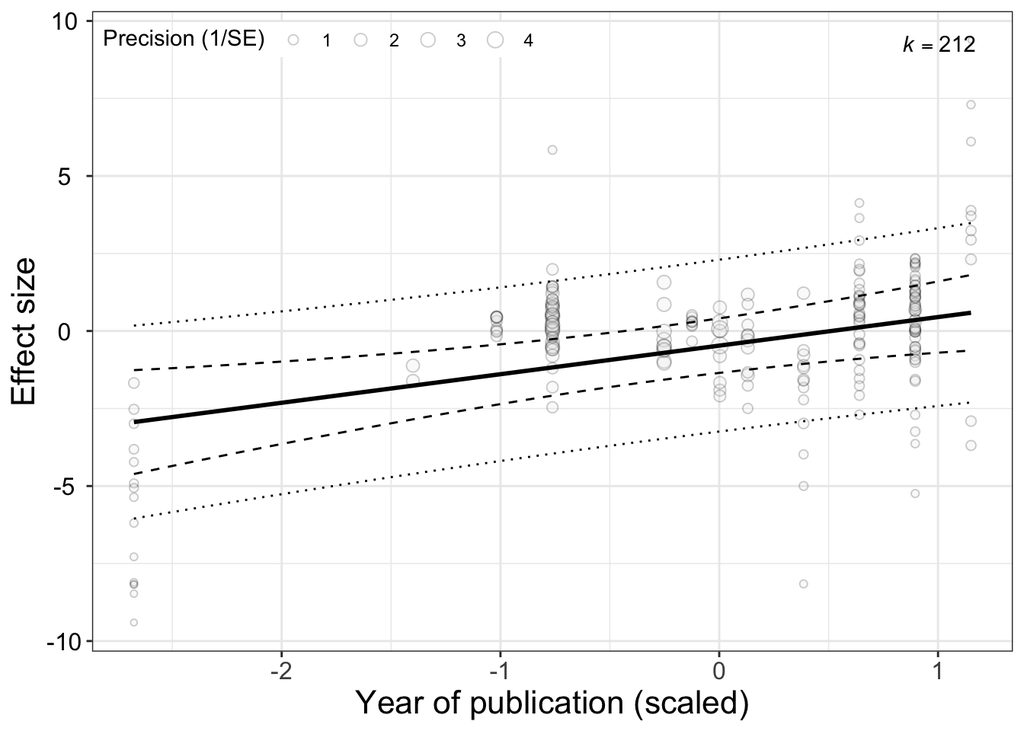

```r
results <- mod_results(model_SMD_tl, mod = "year_scl", group = "StudyID")
time_bias <- orchaRd::bubble_plot(
  model_SMD_tl,
  mod = 'year_scl',
  group = 'StudyID',
  alpha = 0.2,
  cb = FALSE,
  xlab = "Year of publication (scaled)",
  transfm = "none",
) +
  theme(
    axis.text = element_text(size = 12),
    axis.text.y = element_text(size = 12, angle = 0),
    axis.title = element_text(size = 16)
  )

time_bias
```

```r
ggsave(
  filename = here(
    "./03_plots/01_hibernation/06a_overall_plot_hibernation_IM.png"
  ),
  device = 'png',
  plot = time_bias,
  height = 110,
  width = 185,
  units = "mm"
)
ggsave(
  filename = here(
    "./03_plots/01_hibernation/06a_overall_plot_hibernation_IM.pdf"
  ),
  plot = time_bias,
  height = 110,
  width = 185,
  units = "mm"
)
```

## Meta-analysis with all organisms but including different IM markers:

Number of observations for each type:

```r
table(df_SMD$Biomarker_cat_2)
```

```
## < table of extent 0 >
```

```r
model_SMD_biomarker <- rma.mv(
  yi = SMDH,
  V = V,
  mods = ~ Biomarker_category - 1,
  random = list(
    ~ 1 | scientific_name_phylo,
    ~ 1 | Species,
    ~ 1 | obsID,
    ~ 1 | StudyID
  ),
  data = df_SMD,
  R = list(scientific_name_phylo = phylo_cor),
  method = "REML",
  control = list(optimizer = "BFGS"),
  verbose = F
)
```

```r
saveRDS(
  object = model_SMD_biomarker,
  file = here(
    './04_models/01_hibernation/02b_metareg_biomarker_hibernation_IM.RDS'
  )
)
model_SMD_biomarker <- readRDS(
  file = here(
    './04_models/01_hibernation/02b_metareg_biomarker_hibernation_IM.RDS'
  )
)
summary(model_SMD_biomarker)
```

```
##
## Multivariate Meta-Analysis Model (k = 212; method: REML)
##
##    logLik   Deviance        AIC        BIC       AICc
## -374.5298   749.0596   763.0596   786.4559   763.6168
##
## Variance Components:
##
##             estim    sqrt  nlvls  fixed                 factor    R
## sigma^2.1  1.7778  1.3334      9     no  scientific_name_phylo  yes
## sigma^2.2  0.0000  0.0052      9     no                Species   no
## sigma^2.3  0.6506  0.8066    212     no                  obsID   no
## sigma^2.4  0.8987  0.9480     16     no                StudyID   no
##
## Test for Residual Heterogeneity:
## QE(df = 209) = 728.2766, p-val < .0001
##
## Test of Moderators (coefficients 1:3):
## QM(df = 3) = 7.4988, p-val = 0.0576
##
## Model Results:
##
##                             estimate      se     zval    pval    ci.lb   ci.ub
## Biomarker_categoryAdaptive   -1.4821  0.8518  -1.7399  0.0819  -3.1516  0.1874
## Biomarker_categoryBoth       -1.4281  0.8233  -1.7347  0.0828  -3.0416  0.1855
## Biomarker_categoryInnate     -0.9121  0.8158  -1.1180  0.2636  -2.5111  0.6869
##
## Biomarker_categoryAdaptive  .
## Biomarker_categoryBoth      .
## Biomarker_categoryInnate
##
## ---
## Signif. codes:  0 '***' 0.001 '**' 0.01 '*' 0.05 '.' 0.1 ' ' 1
```

### Plot of results of biomarker meta-regression:

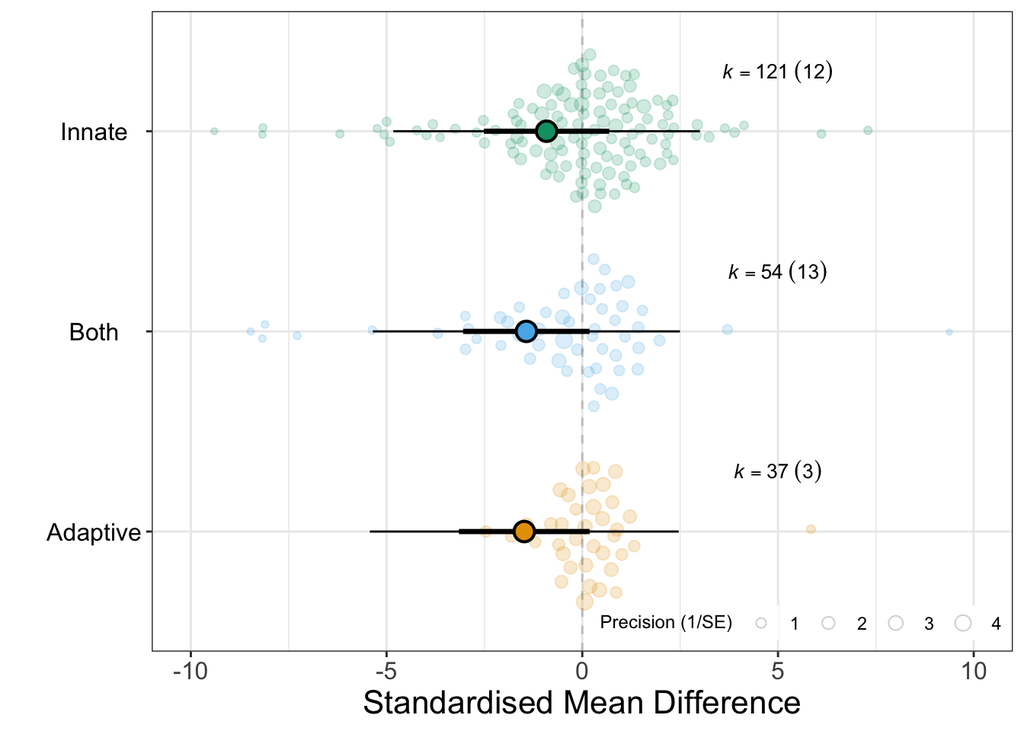

```r
biomarker_plot <- orchard_plot(
  object = model_SMD_biomarker,
  mod = 'Biomarker_category',
  group = 'StudyID',
  k.pos = 5,
  trunk.size = 1,
  alpha = 0.2,
  cb = FALSE,
  xlab = "Standardised Mean Difference",
  transfm = "none"
) +
  scale_fill_okabe_ito() +
  scale_color_okabe_ito() +
  theme(
    axis.text = element_text(size = 12),
    axis.text.y = element_text(size = 12, angle = 0),
    axis.title = element_text(size = 16)
  ) +
  scale_y_continuous(
    limits = c(-10, 10),
    breaks = seq(-10, 10, 5),
    label = seq(-10, 10, 5)
  )

biomarker_plot
```

```r
ggsave(
  filename = here(
    "./03_plots/01_hibernation/02b_biomarker_IM.png"
  ),
  plot = biomarker_plot,
  device = "png",
  height = 110,
  width = 185,
  units = "mm"
)

ggsave(
  filename = here(
    "./03_plots/01_hibernation/02b_biomarker_IM.pdf"
  ),
  plot = biomarker_plot,
  height = 110,
  width = 185,
  units = "mm"
)
```

## Meta-analysis including thermoregulation type as a moderator:

Number of observations for each type:

```r
table(df_SMD$Thermoregulation)
```

```
##
## Ectothermic Endothermic
##          32         186
```

```r
model_SMD_thermoregulation <- rma.mv(
  yi = SMDH,
  V = V,
  mods = ~ Thermoregulation - 1,
  random = list(
    ~ 1 | scientific_name_phylo,
    ~ 1 | Species,
    ~ 1 | obsID,
    ~ 1 | StudyID
  ),
  data = df_SMD,
  R = list(scientific_name_phylo = phylo_cor),
  method = "REML",
  control = list(optimizer = "BFGS"),
  verbose = F
)
```

```r
saveRDS(
  object = model_SMD_thermoregulation,
  file = here(
    './04_models/01_hibernation/03b_metareg_thermoregulation_hibernation_IM.RDS'
  )
)
model_SMD_thermoregulation <- readRDS(
  file = here(
    './04_models/01_hibernation/03b_metareg_thermoregulation_hibernation_IM.RDS'
  )
)
summary(model_SMD_thermoregulation)
```

```
##
## Multivariate Meta-Analysis Model (k = 212; method: REML)
##
##    logLik   Deviance        AIC        BIC       AICc
## -376.1598   752.3196   764.3196   784.4023   764.7334
##
## Variance Components:
##
##             estim    sqrt  nlvls  fixed                 factor    R
## sigma^2.1  1.1475  1.0712      9     no  scientific_name_phylo  yes
## sigma^2.2  0.0000  0.0046      9     no                Species   no
## sigma^2.3  0.6683  0.8175    212     no                  obsID   no
## sigma^2.4  0.9316  0.9652     16     no                StudyID   no
##
## Test for Residual Heterogeneity:
## QE(df = 210) = 724.9054, p-val < .0001
##
## Test of Moderators (coefficients 1:2):
## QM(df = 2) = 4.4504, p-val = 0.1080
##
## Model Results:
##
##                              estimate      se     zval    pval    ci.lb
## ThermoregulationEctothermic   -2.0253  0.9601  -2.1095  0.0349  -3.9071
## ThermoregulationEndothermic   -0.1938  0.8984  -0.2157  0.8292  -1.9547
##                                ci.ub
## ThermoregulationEctothermic  -0.1435  *
## ThermoregulationEndothermic   1.5671
##
## ---
## Signif. codes:  0 '***' 0.001 '**' 0.01 '*' 0.05 '.' 0.1 ' ' 1
```

### Plot of results of thermoregulation meta-regression:

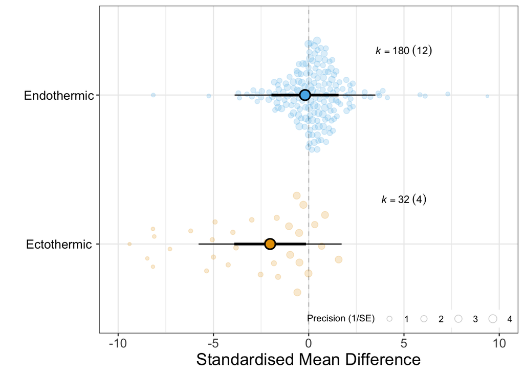

```r
thermo_plot <- orchard_plot(
  object = model_SMD_thermoregulation,
  mod = 'Thermoregulation',
  group = 'StudyID',
  k.pos = 5,
  trunk.size = 1,
  alpha = 0.2,
  cb = FALSE,
  xlab = "Standardised Mean Difference",
  transfm = "none"
) +
  scale_fill_okabe_ito() +
  scale_color_okabe_ito() +
  theme(
    axis.text = element_text(size = 12),
    axis.text.y = element_text(size = 12, angle = 0),
    axis.title = element_text(size = 16)
  ) +
  scale_y_continuous(
    limits = c(-10, 10),
    breaks = seq(-10, 10, 5),
    label = seq(-10, 10, 5)
  )

thermo_plot
```

```r
ggsave(
  filename = here(
    "./03_plots/01_hibernation/03b_thermoregulation_plot_IM.png"
  ),
  plot = thermo_plot,
  device = "png",
  height = 120,
  width = 185,
  units = "mm"
)

ggsave(
  filename = here(
    "./03_plots/01_hibernation/03b_thermoregulation_plot_IM.pdf"
  ),
  plot = thermo_plot,
  height = 120,
  width = 185,
  units = "mm"
)
```

## Endotherms vs. ectotherms:

```r
table(df_SMD$Biomarker_cat_2)
```

```
## < table of extent 0 >
```

### Meta-model for endotherms:

```r
## data for SMD
df_SMD_endo <- df_SMD %>%
  filter(!is.na(SMDH)) %>%
  filter(!is.na(SMDH.sv)) %>%
  filter(Thermoregulation == 'Endothermic')

## calculate var-cover matrix to control for correlated effect sizes within study and tissue
V_endo <- vcalc(
  vi = SMDH.sv,
  cluster = StudyID,
  subgroup = Tissue,
  grp1 = Hib_M,
  grp2 = Euthermia_M,
  w1 = Hib_N,
  w2 = Euthermia_N,
  data = df_SMD_endo
)
```

- Number of observation with non-missing SMD: 186
- Number of studies in the dataset for analysis: 13
- Number of species in the dataset for analysis: 7

```r
model_SMD_endo <- rma.mv(
  yi = SMDH,
  V = V_endo,
  mods = ~ Biomarker_category - 1,
  random = list(
    ~ 1 | scientific_name_phylo,
    ~ 1 | Species,
    ~ 1 | obsID,
    ~ 1 | StudyID
  ),
  data = df_SMD_endo,
  R = list(scientific_name_phylo = phylo_cor),
  method = "REML",
  control = list(optimizer = "BFGS"),
  verbose = F
)
```

```r
saveRDS(
  object = model_SMD_endo,
  file = here(
    './04_models/01_hibernation/04b_metareg_hibernation_endo_IM.RDS'
  )
)
model_SMD_endo <- readRDS(
  file = here(
    './04_models/01_hibernation/04b_metareg_hibernation_endo_IM.RDS'
  )
)
summary(model_SMD_endo)
```

```
##
## Multivariate Meta-Analysis Model (k = 180; method: REML)
##
##    logLik   Deviance        AIC        BIC       AICc
## -309.2509   618.5018   632.5018   654.7348   633.1645
##
## Variance Components:
##
##             estim    sqrt  nlvls  fixed                 factor    R
## sigma^2.1  0.0000  0.0050      6     no  scientific_name_phylo  yes
## sigma^2.2  0.0000  0.0040      6     no                Species   no
## sigma^2.3  0.6479  0.8049    180     no                  obsID   no
## sigma^2.4  0.7028  0.8383     12     no                StudyID   no
##
## Test for Residual Heterogeneity:
## QE(df = 177) = 566.2446, p-val < .0001
##
## Test of Moderators (coefficients 1:3):
## QM(df = 3) = 5.2994, p-val = 0.1511
##
## Model Results:
##
##                             estimate      se     zval    pval    ci.lb   ci.ub
## Biomarker_categoryAdaptive   -0.1599  0.3587  -0.4458  0.6557  -0.8630  0.5431
## Biomarker_categoryBoth       -0.1159  0.3070  -0.3775  0.7058  -0.7175  0.4858
## Biomarker_categoryInnate      0.4251  0.3066   1.3867  0.1655  -0.1757  1.0260
##
## Biomarker_categoryAdaptive
## Biomarker_categoryBoth
## Biomarker_categoryInnate
##
## ---
## Signif. codes:  0 '***' 0.001 '**' 0.01 '*' 0.05 '.' 0.1 ' ' 1
```

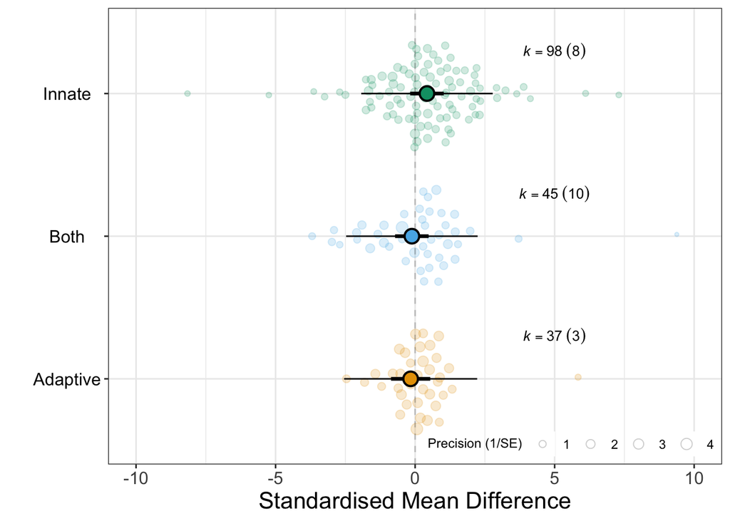

```r
endo_plot <- orchard_plot(
  object = model_SMD_endo,
  mod = 'Biomarker_category',
  group = 'StudyID',
  k.pos = 5,
  trunk.size = 1,
  alpha = 0.2,
  cb = FALSE,
  xlab = "Standardised Mean Difference",
  transfm = "none"
) +
  scale_fill_okabe_ito() +
  scale_color_okabe_ito() +
  theme(
    axis.text = element_text(size = 12),
    axis.text.y = element_text(size = 12, angle = 0),
    axis.title = element_text(size = 16)
  ) +
  scale_y_continuous(
    limits = c(-10, 10),
    breaks = seq(-10, 10, 5),
    label = seq(-10, 10, 5)
  )

endo_plot
```

```r
ggsave(
  filename = here(
    "./03_plots/01_hibernation/04b_endo_plot_IM.png"
  ),
  plot = endo_plot,
  device = "png",
  height = 120,
  width = 185,
  units = "mm"
)

ggsave(
  filename = here(
    "./03_plots/01_hibernation/04b_endo_plot_IM.pdf"
  ),
  plot = endo_plot,
  height = 120,
  width = 185,
  units = "mm"
)
```

### Meta-model for ectotherms:

```r
## data for SMD
df_SMD_ecto <- df_SMD %>%
  filter(!is.na(SMDH)) %>%
  filter(!is.na(SMDH.sv)) %>%
  filter(Thermoregulation == 'Ectothermic')

## calculate var-cover matrix to control for correlated effect sizes within study and tissue
V_ecto <- vcalc(
  vi = SMDH.sv,
  cluster = StudyID,
  subgroup = Tissue,
  grp1 = Hib_M,
  grp2 = Euthermia_M,
  w1 = Hib_N,
  w2 = Euthermia_N,
  data = df_SMD_ecto
)
```

- Number of observation with non-missing SMD: 32
- Number of studies in the dataset for analysis: 4
- Number of species in the dataset for analysis: 3

```r
model_SMD_ecto <- rma.mv(
  yi = SMDH,
  V = V_ecto,
  mods = ~ Biomarker_category - 1,
  random = list(
    ~ 1 | StudyID,
    ~ 1 | scientific_name_phylo,
    ~ 1 | Species,
    ~ 1 | obsID
  ),
  data = df_SMD_ecto,
  R = list(scientific_name_phylo = phylo_cor),
  method = "REML"
)
```

```r
saveRDS(
  object = model_SMD_ecto,
  file = here(
    './04_models/01_hibernation/05b_metareg_ecto_hibernation_IM.RDS'
  )
)
model_SMD_ecto <- readRDS(
  file = here(
    './04_models/01_hibernation/05b_metareg_ecto_hibernation_IM.RDS'
  )
)
summary(model_SMD_ecto)
```

```
##
## Multivariate Meta-Analysis Model (k = 32; method: REML)
##
##   logLik  Deviance       AIC       BIC      AICc
## -58.6493  117.2985  129.2985  137.7057  132.9507
##
## Variance Components:
##
##             estim    sqrt  nlvls  fixed                 factor    R
## sigma^2.1  2.2986  1.5161      4     no                StudyID   no
## sigma^2.2  2.9808  1.7265      3     no  scientific_name_phylo  yes
## sigma^2.3  0.0000  0.0002      3     no                Species   no
## sigma^2.4  0.7513  0.8668     32     no                  obsID   no
##
## Test for Residual Heterogeneity:
## QE(df = 30) = 145.4620, p-val < .0001
##
## Test of Moderators (coefficients 1:2):
## QM(df = 2) = 2.5651, p-val = 0.2773
##
## Model Results:
##
##                           estimate      se     zval    pval    ci.lb   ci.ub
## Biomarker_categoryBoth     -2.4572  1.5635  -1.5716  0.1160  -5.5216  0.6071
## Biomarker_categoryInnate   -2.0128  1.4986  -1.3431  0.1792  -4.9501  0.9244
##
## ---
## Signif. codes:  0 '***' 0.001 '**' 0.01 '*' 0.05 '.' 0.1 ' ' 1
```

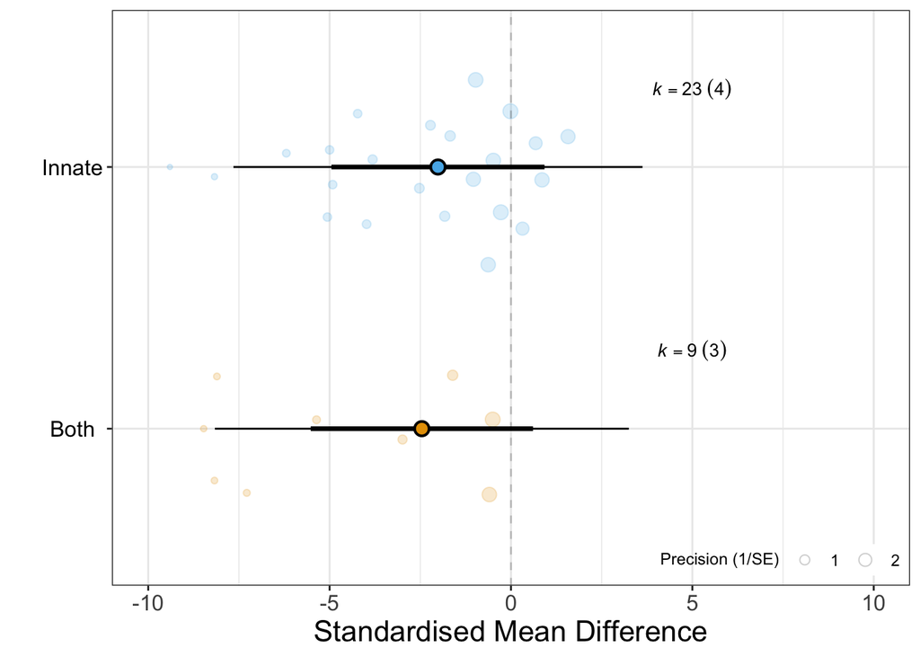

```r
ecto_plot <- orchard_plot(
  object = model_SMD_ecto,
  mod = 'Biomarker_category',
  group = 'StudyID',
  k.pos = 5,
  trunk.size = 0.75,
  alpha = 0.2,
  cb = FALSE,
  xlab = "Standardised Mean Difference",
  transfm = "none"
) +
  scale_fill_okabe_ito() +
  scale_color_okabe_ito() +
  theme(
    axis.text = element_text(size = 12),
    axis.text.y = element_text(size = 12, angle = 0),
    axis.title = element_text(size = 16)
  ) +
  scale_y_continuous(
    limits = c(-10, 10),
    breaks = seq(-10, 10, 5),
    label = seq(-10, 10, 5)
  )

ecto_plot
```

```r
ggsave(
  filename = here(
    "./03_plots/01_hibernation/05b_ecto_plot_IM.png"
  ),
  plot = ecto_plot,
  device = "png",
  height = 120,
  width = 185,
  units = "mm"
)

ggsave(
  filename = here(
    "./03_plots/01_hibernation/05b_ecto_plot_IM.pdf"
  ),
  plot = ecto_plot,
  height = 120,
  width = 185,
  units = "mm"
)
```